# Artigo Final - Análise de Dados - códigos

setwd(“C:\Users\otavi\Downloads”)

Os dados para reprodução desta pesquisa estão disponíveis no seguinte endereço: https://www.dropbox.com/sh/uwixp5lccxdap92/AABee1oKHWB6kOoOFPDq4Umaa?dl=0

```r
library(tidyverse)
library(readr)
library(readxl)
library(haven)
library(dplyr)
library(poliscidata)
library(vcd)
```

```r
library(graphics)
library(scales)
library(dotwhisker)
library(pscl)
library(ggplot2)
```

#Download dos bancos de dados

##Variável dependente

```r
IPC_TI_linhas <- read_excel("C:/Users/otavi/Downloads/IPC2019.xlsx")

IPC_TI <- IPC_TI_linhas[c(-46, -67, -92, -131, -132, -134, -138, -144, -155),]
```

O Índice de percepção de corrupção de 2019 foi baixado do banco de dados da Transparência Internacional (https://www.transparency.org/en/cpi/2019/results)

##Variáveis independentes

##Liberdade da mídia

Foi baixado o banco de dados da V-dem, de onde foram selecionadas as variáveis relativas à liberdade da imprensa (https://www.v-dem.net/en/data/data-version-10/).

```r
vdem <- read_sav("V-Dem-CD-v10.sav")

vdem_filtrado <- vdem %>%
  filter(year == "2018")

vdem_renomeado <- vdem_filtrado %>%
  rename(Country = country_name)

v_dem_na <- vdem_renomeado %>%
  select(Country, year, v2meharjrn, v2merange, v2mecrit)
```

Fora omitidas as observações NA

```r
v_dem_linhas <-na.omit(v_dem_na)
```

Foi necessário renomear algumas observações para que todas tivessem a mesma escrita na coluna Country.

```r
v_dem_linhas[64,1] <- "Cabo Verde"
v_dem_linhas[106,1] <- "Congo"
v_dem_linhas[111,1] <- "Gambia"
v_dem_linhas[113,1] <- "Guinea Bissau"

v_dem <- v_dem_linhas[c(-8, -26, -27, -28, -32, -35, -37, -42, -45, -47, -55, -58, -73, -90, -91, -109, -115, -122, -124, -126, -129, -131, -132, -138, -148, -160, -171, -173, -176, -178, -180),]
```

#Variáveis de controle

As variáveis de controle foram retiradas de diferentes bancos de dados, tendo o PIB sido baixado do Banco Mundial, onde é possível realizar o download apenas da variável desejada, sem que haja a necessidade de baixar o banco inteiro (https://data.worldbank.org/indicator/NY.GDP.PCAP.CD).

```r
PIB_linhas <- read_csv2("C:/Users/otavi/Downloads/WB-PIB.CSV")
```

```
## i Using ',' as decimal and '.' as grouping mark. Use `read_delim()` for more control.
```

```r
PIB_selecionado <- PIB_linhas %>%
  select(Country, "2018")

PIB_selecionado_renomeado <- PIB_selecionado %>%
  rename(PIB2018 = "2018")

PIB_final <- PIB_selecionado_renomeado[c(-126),]
```

O IDH, por sua vez, foi retirado do banco de dados do Programa de Desenvolvimento das Nações Unidas (http://hdr.undp.org/en/content/human-development-index-hdi), onde também não há necessidade de realização do download do banco inteiro, apenas da variável desejada.

```r
IDH_completo <- read_excel("C:/Users/otavi/Downloads/hdro_statistical_data_table_2.xlsx")
```

```
## * `` -> ...4
## * `` -> ...6
## * `` -> ...8
## * `` -> ...10
## * `` -> ...12
## * ...
```

```r
IDH_linhas <- IDH_completo %>%
  select(Country, "2018")

IDH_final <- IDH_linhas[c(-46, -67, -91, -131, -132, -134, -144, -138, -155),]
```

A variável de qualidade da democracia foi baixada a partir do site da Freedom House, sem necessidade de baixar o banco inteiro

```r
Qualidade_democ_2018 <- read_excel("C:/Users/otavi/Downloads/quali_democ_2018.xlsx", sheet=2)

quali_democ_2018_linhas <- Qualidade_democ_2018 %>%
  select("Country", "Total")

quali_democ_2018 <- quali_democ_2018_linhas[c(-46, -67, -91, -131, -132, -134, -138, -144, -155),]
```

Foram excluídas linhas dos bancos para garantir que todos contassem com exatamente as mesmas observações na coluna Country.

#Banco de dados completo

Por meio da função merge juntou-se todos os bancos, formando um banco completo, em que as colunas seleciondas em cada banco foram transformadas em variáveis para ser possível realizar as correções e regressões.

```r
Banco_parcial <- merge(PIB_final,
                        IDH_final,
                        by= "Country")

Banco_parcial_2 <- merge(Banco_parcial,
                         quali_democ_2018,
                         by= "Country")

Banco_parcial_3 <- merge(Banco_parcial_2,
                         IPC_TI,
                         by= "Country")

Banco_completo <- merge(Banco_parcial_3,
                         v_dem,
                         by= "Country")

Banco_completo_renomeado <- Banco_completo %>%
  rename(IPC = 'CPI score 2019', PIB = PIB2018, IDH = "2018", quali_democracia = Total)
```

#Descrição gráfica das variáveis

As variáveis analisadas são contínuas, sendo assim, foram escolhidos os gráficos adequados para sua representação.

##IPC

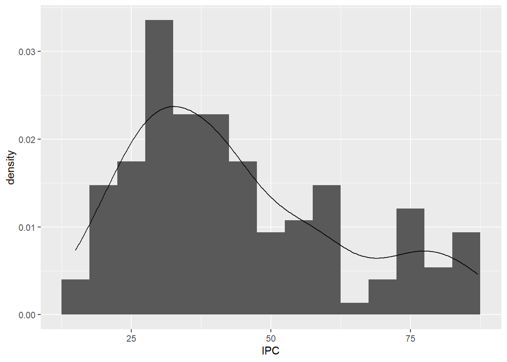

```r
ggplot(Banco_completo_renomeado, aes(IPC)) +
  geom_histogram(aes(y=..density..),
                 binwidth=5) +
  geom_density()
```

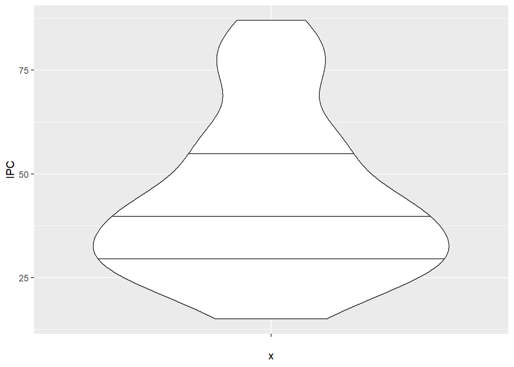

```r
ggplot(Banco_completo_renomeado,
       aes(x = "", y = IPC)) +
  geom_violin(draw_quantiles = c(0.25, 0.5, 0.75))
```

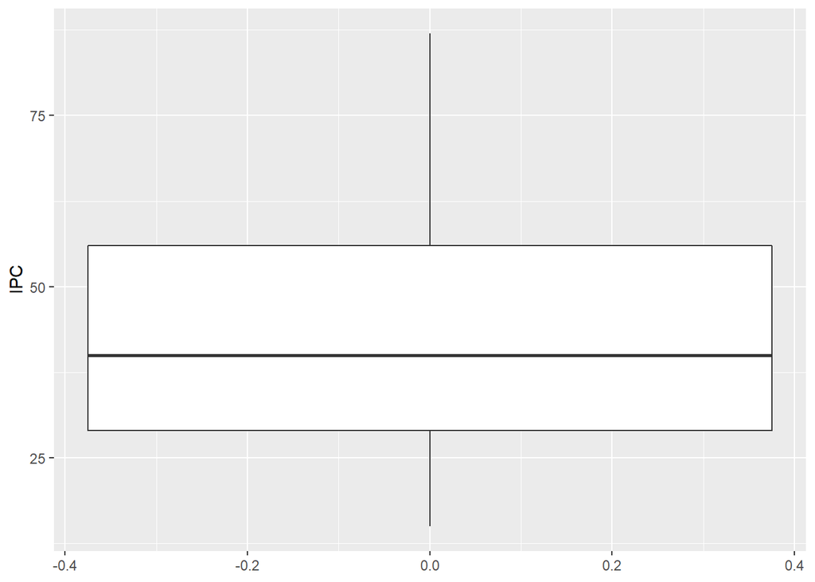

```r
ggplot(Banco_completo_renomeado, aes(y = IPC)) +
  geom_boxplot()
```

##PIB

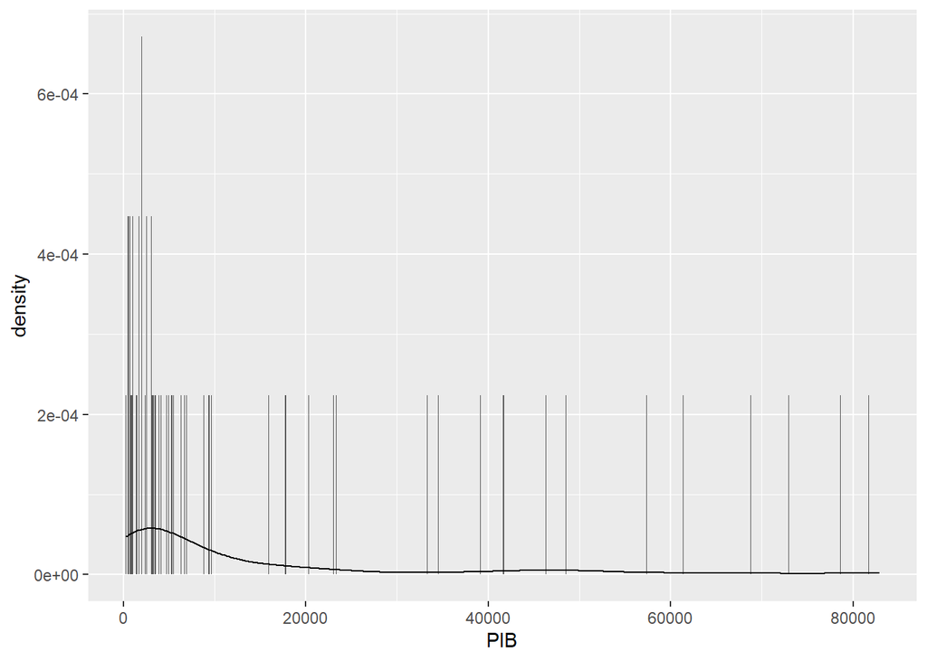

```r
ggplot(Banco_completo_renomeado, aes(PIB)) +
  geom_histogram(aes(y=..density..),
                 binwidth=30) +
  geom_density()
```

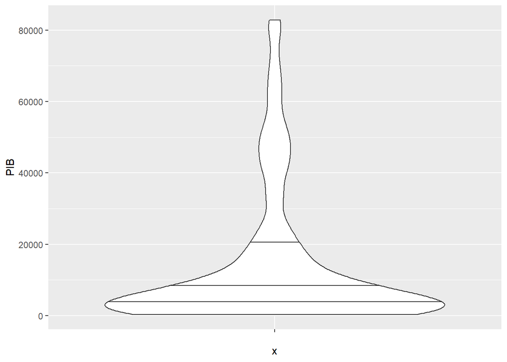

```r
ggplot(Banco_completo_renomeado,
       aes(x = "", y = PIB)) +
  geom_violin(draw_quantiles = c(0.25, 0.5, 0.75))
```

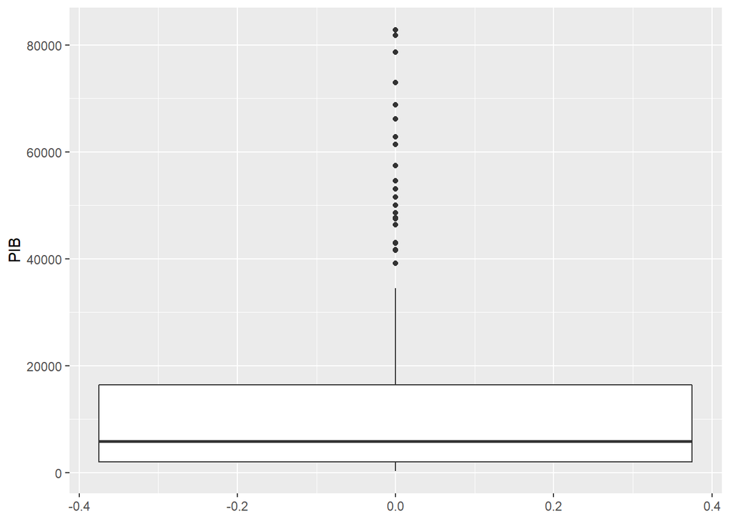

```r
ggplot(Banco_completo_renomeado, aes(y = PIB)) +
  geom_boxplot()
```

##IDH

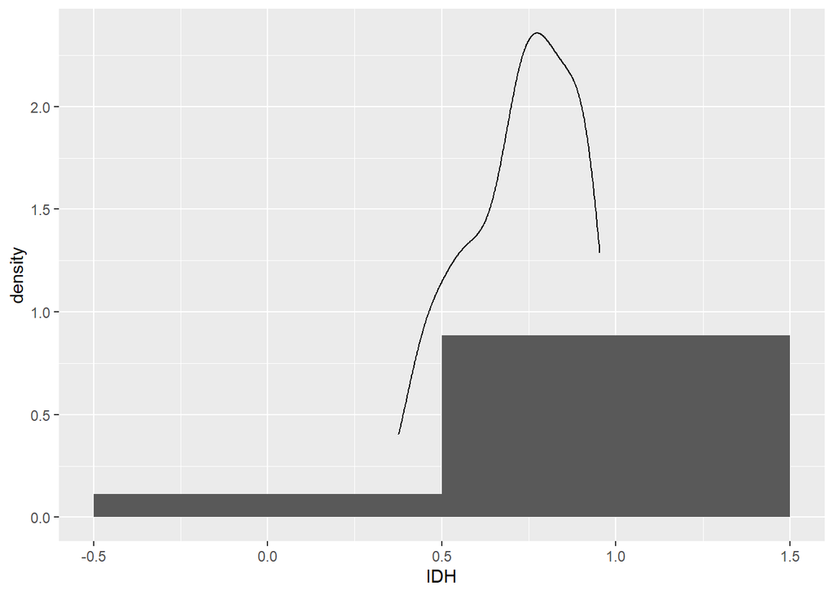

```r
ggplot(Banco_completo_renomeado, aes(IDH)) +
  geom_histogram(aes(y=..density..),
                 binwidth=1) +
  geom_density()
```

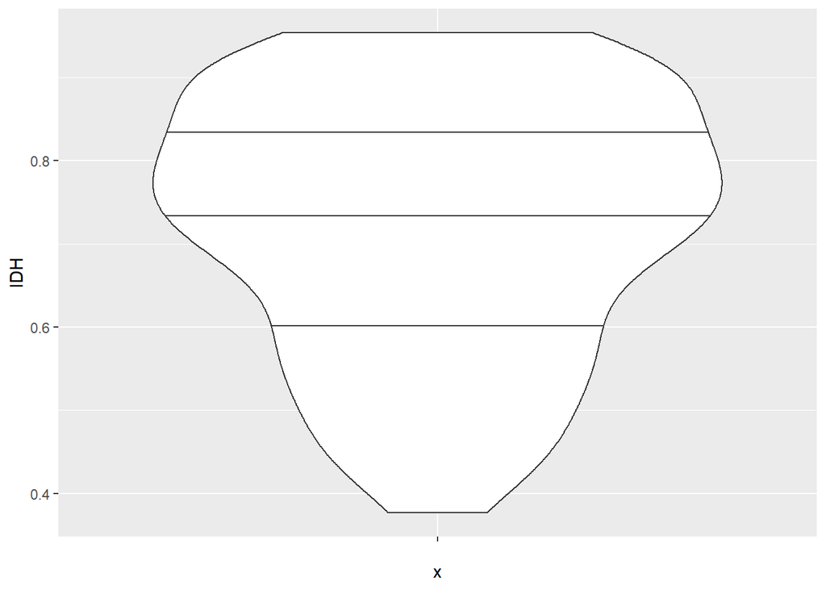

```r
ggplot(Banco_completo_renomeado,
       aes(x = "", y = IDH)) +
  geom_violin(draw_quantiles = c(0.25, 0.5, 0.75))
```

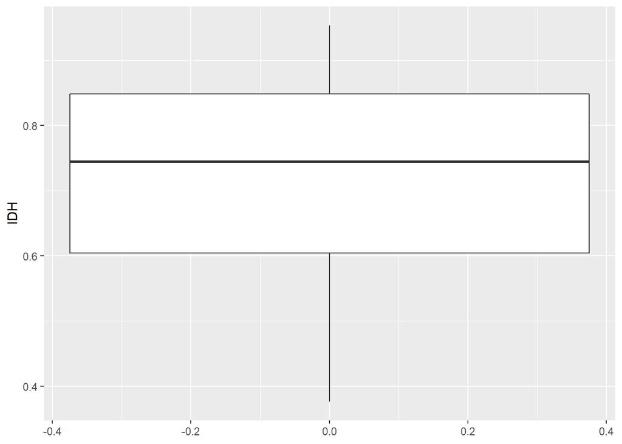

```r
ggplot(Banco_completo_renomeado, aes(y = IDH)) +
  geom_boxplot()
```

##Qualidade da democracia

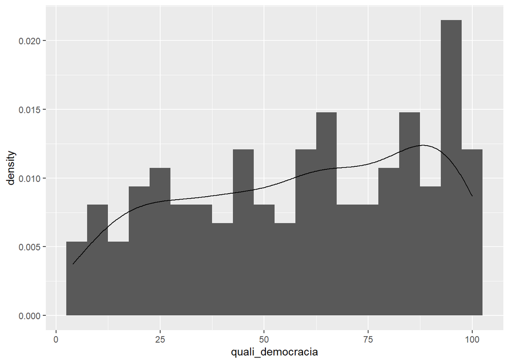

```r
ggplot(Banco_completo_renomeado, aes(quali_democracia)) +
  geom_histogram(aes(y=..density..),
                 binwidth=5) +
  geom_density()
```

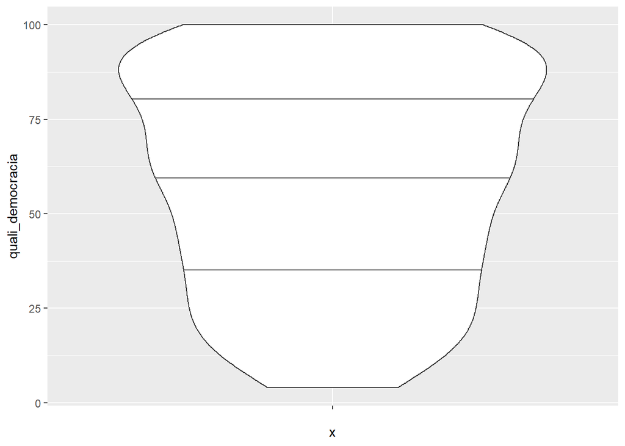

```r
ggplot(Banco_completo_renomeado,
       aes(x = "", y = quali_democracia)) +
  geom_violin(draw_quantiles = c(0.25, 0.5, 0.75))
```

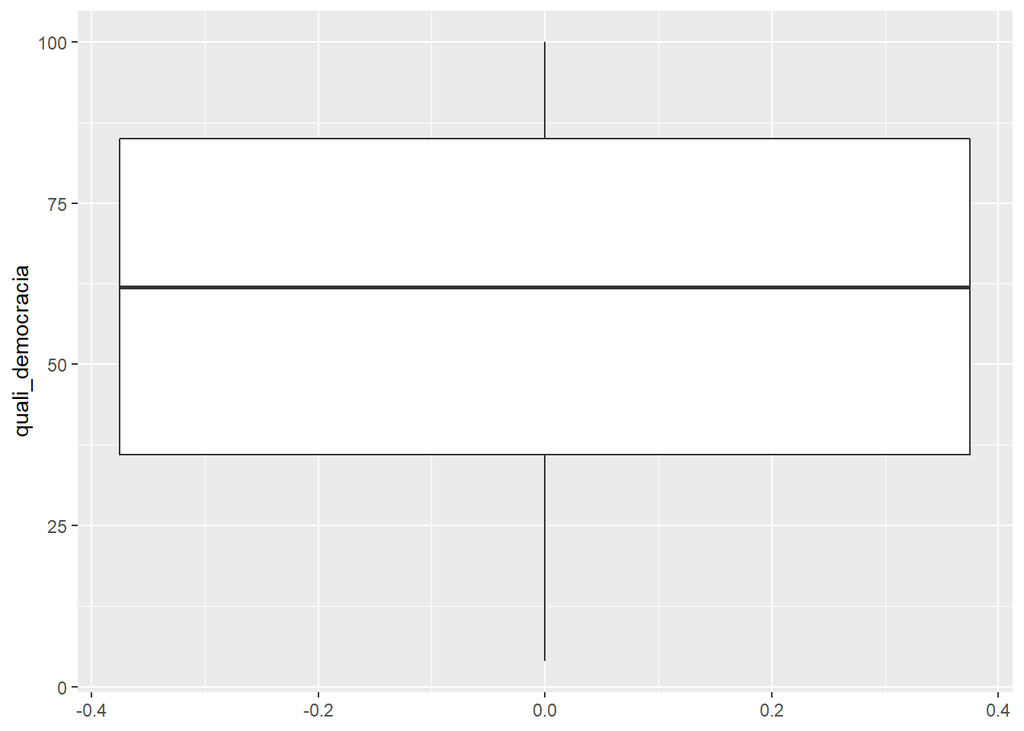

```r
ggplot(Banco_completo_renomeado, aes(y = quali_democracia)) +
  geom_boxplot()
```

##Variáveis relativas à liberdade da mídia

##v2meharjrn

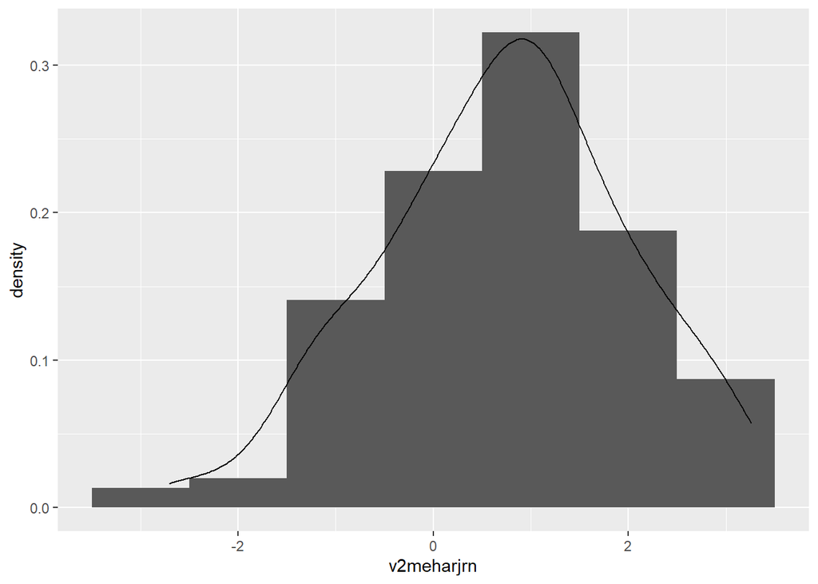

```r
ggplot(Banco_completo_renomeado, aes(v2meharjrn)) +
  geom_histogram(aes(y=..density..),
                 binwidth=1) +
  geom_density()
```

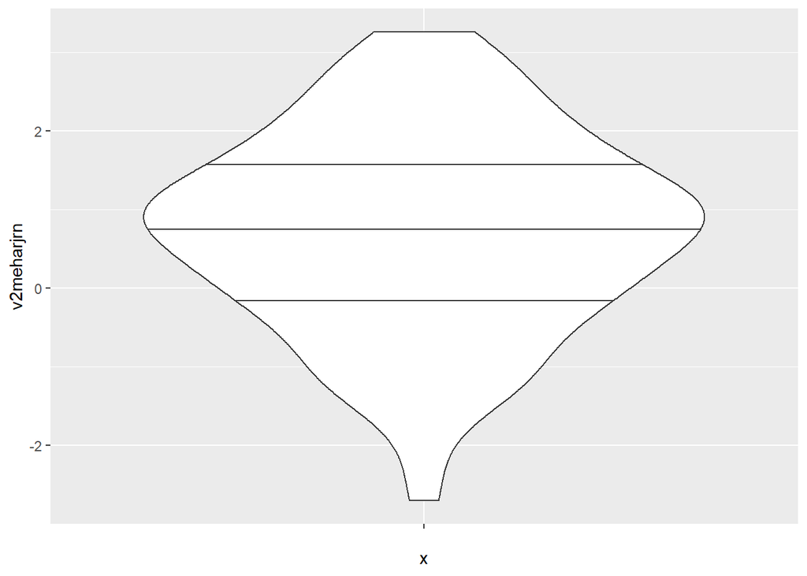

```r
ggplot(Banco_completo_renomeado,
       aes(x = "", y = v2meharjrn)) +
  geom_violin(draw_quantiles = c(0.25, 0.5, 0.75))
```

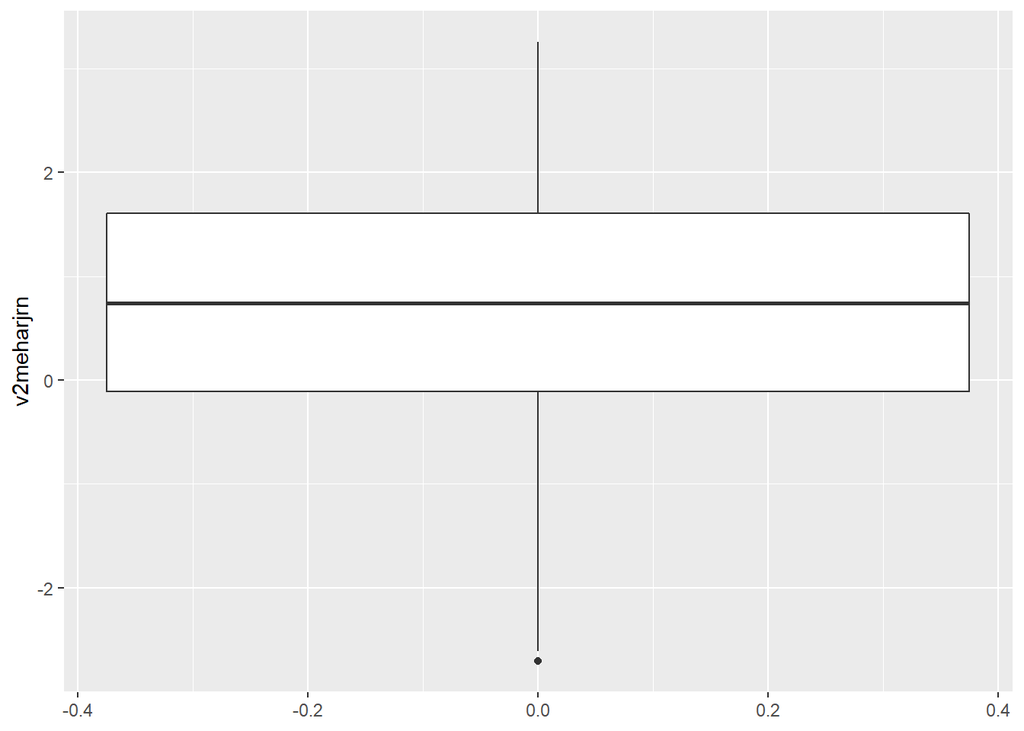

```r
ggplot(Banco_completo_renomeado, aes(y = v2meharjrn)) +
  geom_boxplot()
```

##v2merange

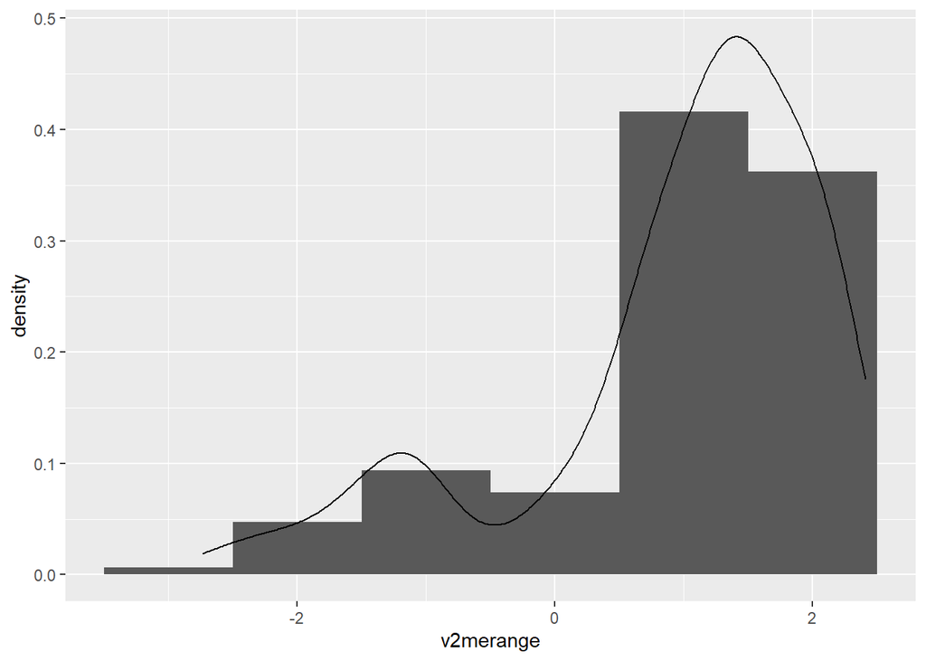

```r
ggplot(Banco_completo_renomeado, aes(v2merange)) +
  geom_histogram(aes(y=..density..),
                 binwidth=1) +
  geom_density()
```

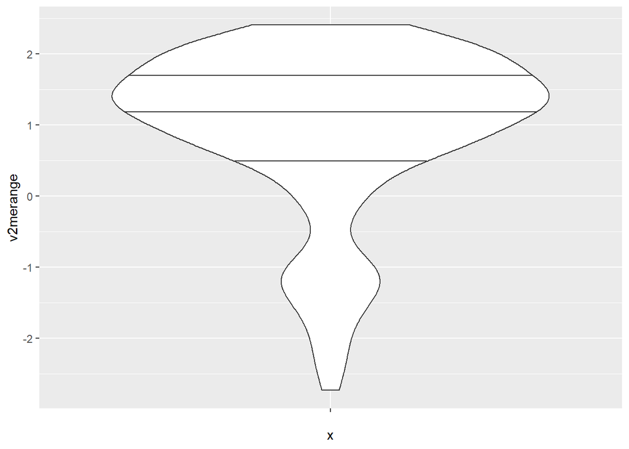

```r
ggplot(Banco_completo_renomeado,
       aes(x = "", y = v2merange)) +
  geom_violin(draw_quantiles = c(0.25, 0.5, 0.75))
```

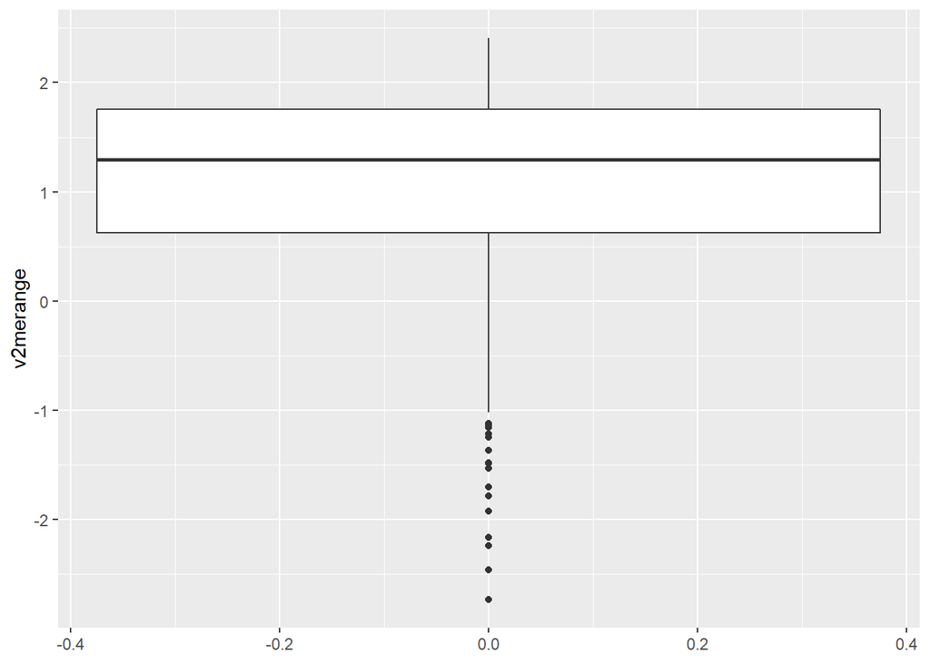

```r
ggplot(Banco_completo_renomeado, aes(y = v2merange)) +
  geom_boxplot()
```

##v2mecrit

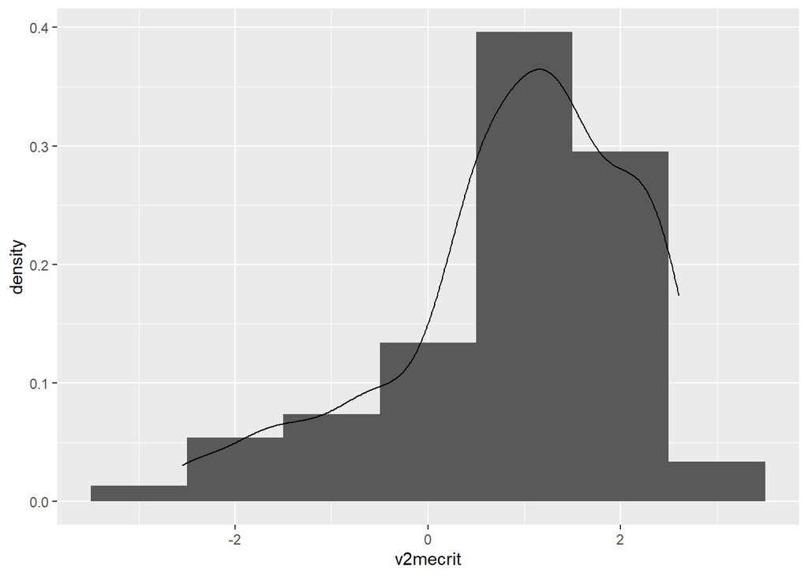

```r
ggplot(Banco_completo_renomeado, aes(v2mecrit)) +
  geom_histogram(aes(y=..density..),
                 binwidth=1) +
  geom_density()
```

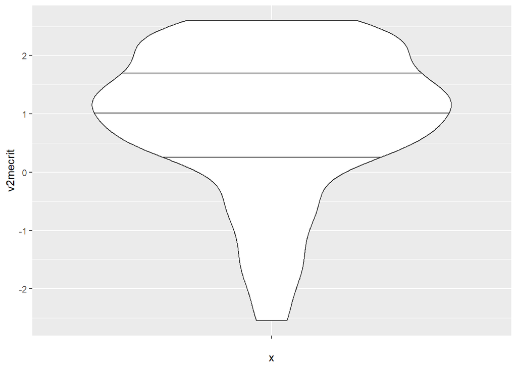

```r
ggplot(Banco_completo_renomeado,
       aes(x = "", y = v2mecrit)) +
  geom_violin(draw_quantiles = c(0.25, 0.5, 0.75))
```

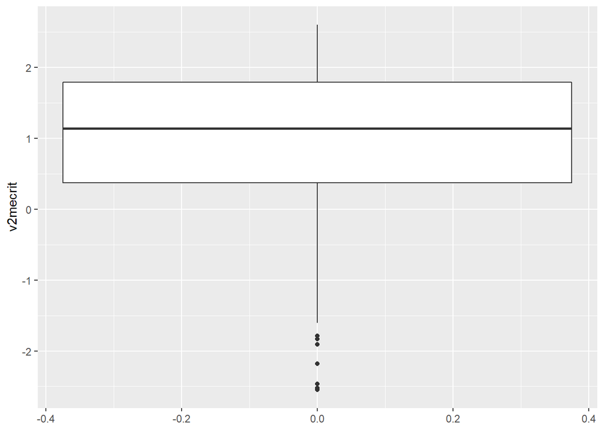

```r
ggplot(Banco_completo_renomeado, aes(y = v2mecrit)) +
  geom_boxplot()
```

#Interações entre as variáveis

Foram plotados gráficos com a finalidade de analisar as interações entre as variáveis.

##PIBxIPC

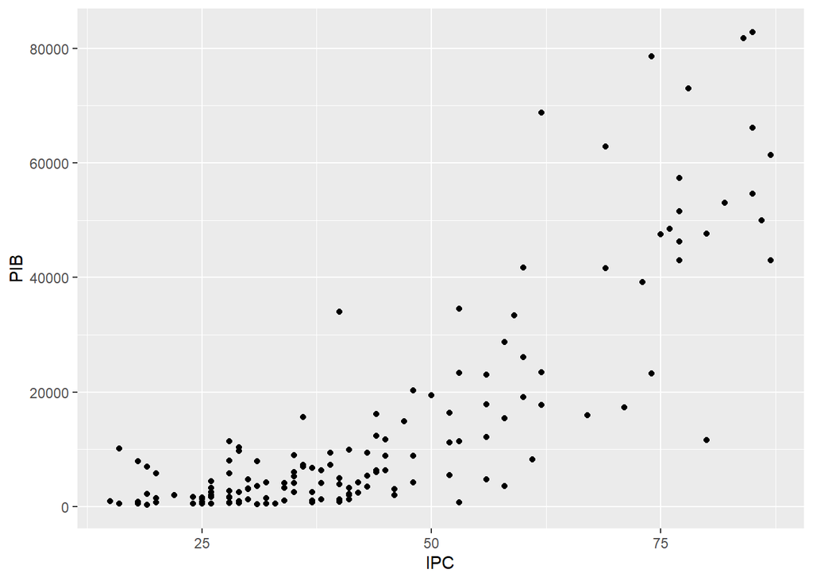

```r
ggplot(Banco_completo_renomeado,
       aes(IPC, PIB)) +
  geom_point(alpha = 1)
```

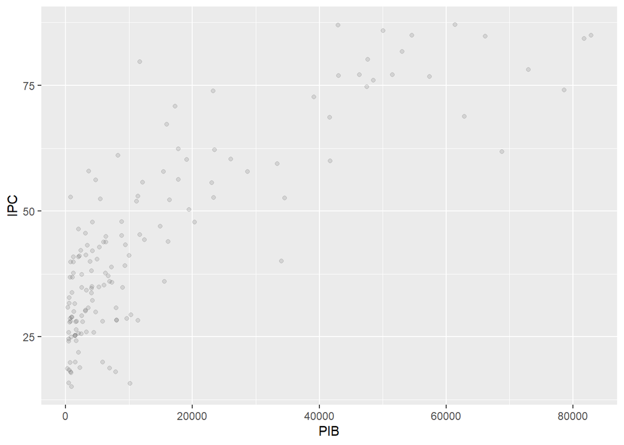

```r
ggplot(Banco_completo_renomeado, aes(PIB, IPC)) +
  geom_jitter(alpha = 0.1)
```

##IDHxIPC

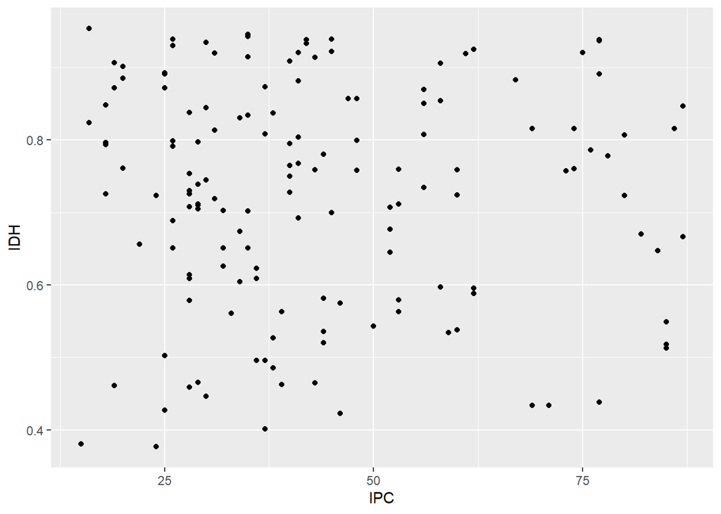

```r
ggplot(Banco_completo_renomeado,
       aes(IPC, IDH)) +
  geom_point(alpha = 1)
```

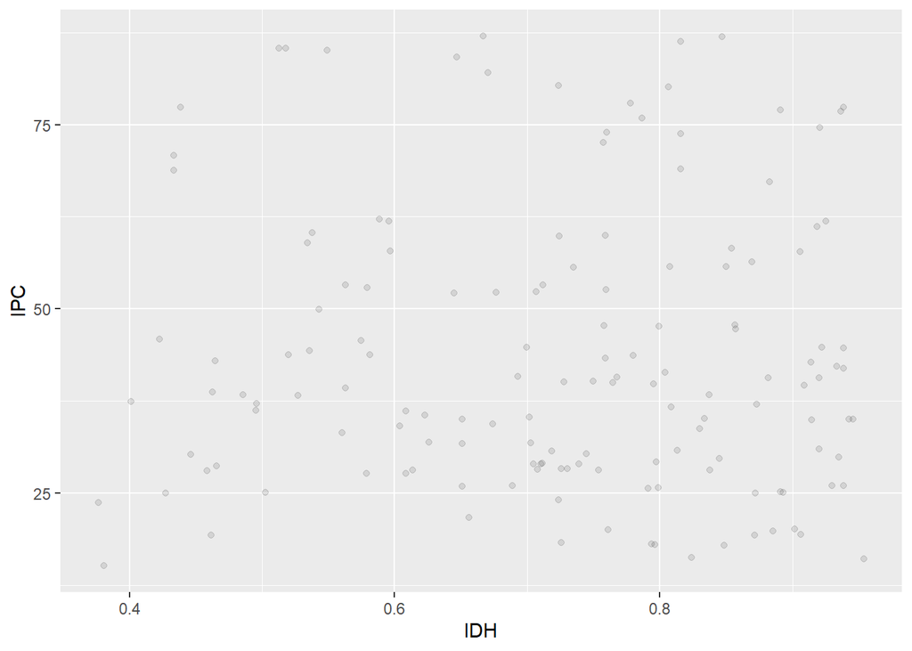

```r
ggplot(Banco_completo_renomeado, aes(IDH, IPC)) +
  geom_jitter(alpha = 0.1)
```

##Qualidade da democracia

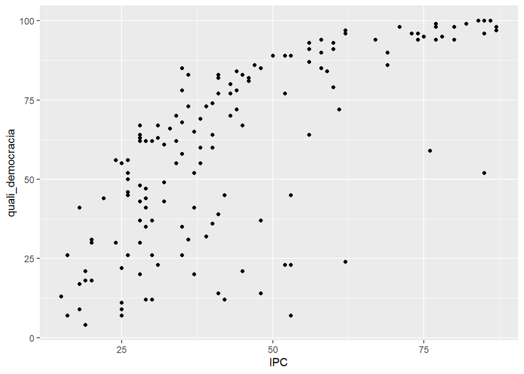

```r
ggplot(Banco_completo_renomeado,
       aes(IPC, quali_democracia)) +
  geom_point(alpha = 1)
```

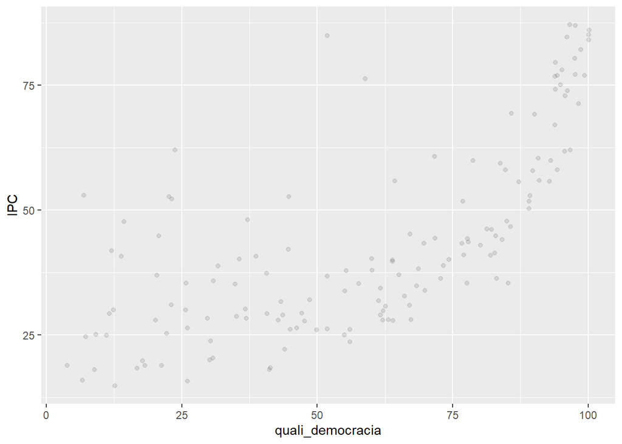

```r
ggplot(Banco_completo_renomeado, aes(quali_democracia, IPC)) +
  geom_jitter(alpha = 0.1)
```

##Variáveis relativas à liberdade da mídia

##v2meharjrn]

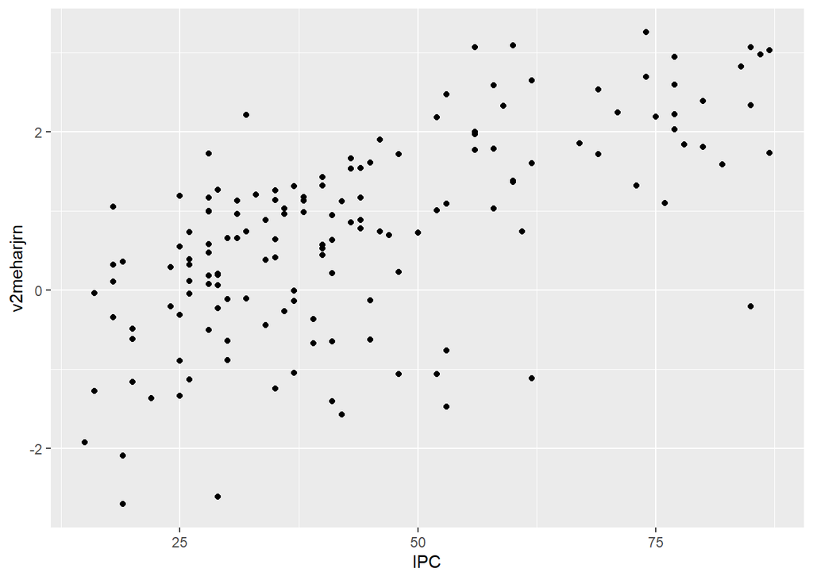

```r
ggplot(Banco_completo_renomeado,
       aes(IPC, v2meharjrn)) +
  geom_point(alpha = 1)
```

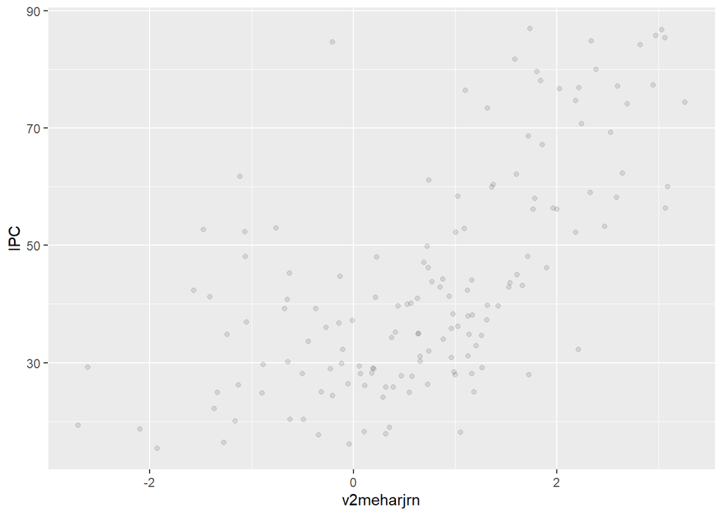

```r
ggplot(Banco_completo_renomeado, aes(v2meharjrn, IPC)) +
  geom_jitter(alpha = 0.1)
```

##v2merange

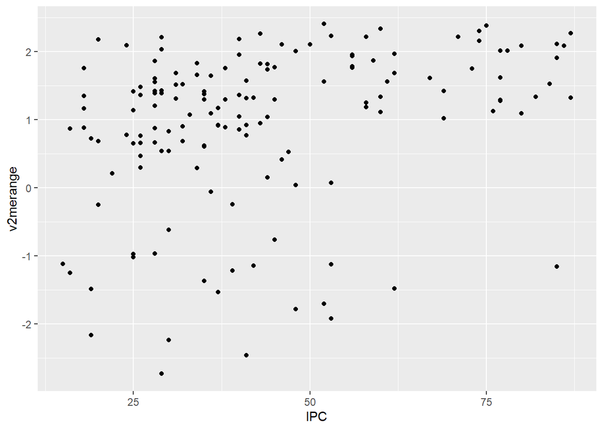

```r
ggplot(Banco_completo_renomeado,
       aes(IPC, v2merange)) +
  geom_point(alpha = 1)
```